# Large CIs in mixed effect model

Clay Ford

2022-04-05

## The data

```r
library(lme4)
library(emmeans)
library(ggplot2)

LitterCN <- read.table("Litter20192020.txt", header = TRUE)
LitterCN$Age <- factor(LitterCN$Age)
LitterCN$Plot <- factor(LitterCN$Plot)
LitterCN$Year <- factor(LitterCN$Year)
```

Notice the response variable ranges from 0.9 to 3.2.

```r
summary(LitterCN$N_perc)
```

```
##    Min. 1st Qu.  Median    Mean 3rd Qu.    Max.
##  0.9149  1.3709  1.6825  1.7726  2.1190  3.2110
```

Quick visual.

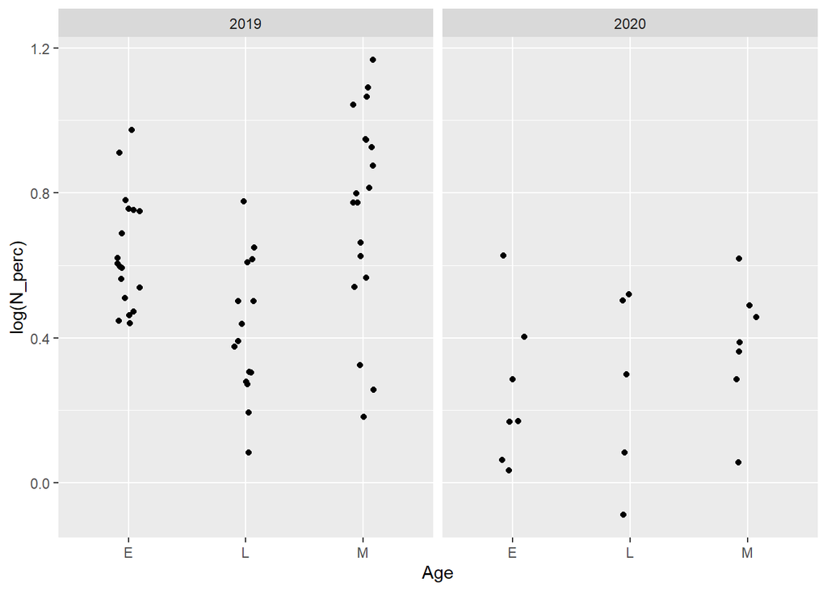

```r
ggplot(LitterCN) +
  aes(x = Age, y = log(N_perc)) +
  geom_jitter(width = 0.1, height = 0) +
  facet_grid(~ Year)
```

The goal is to model N_perc as a function of Age taking into account that there are clsters of measures within Plots that are nested within Years.

```r
xtabs(~ Plot + Year, data = LitterCN)
```

```
##      Year
## Plot  2019 2020
##   E1A    2    1
##   E1B    1    0
##   E1C    2    1
##   E1D    3    1
##   E1E    2    1
##   E2A    3    0
##   E2B    0    1
##   E2D    2    1
##   E2E    3    1
##   L1A    2    0
##   L1B    2    1
##   L1C    2    1
##   L1D    0    1
##   L1E    3    0
##   L2A    2    0
##   L2B    0    1
##   L2C    2    1
##   L2E    2    0
##   M1A    2    1
##   M1B    2    1
##   M1C    2    1
##   M1D    3    1
##   M1E    2    0
##   M2A    3    1
##   M2B    3    0
##   M2C    0    1
##   M2E    2    1
```

Notice all the zeroes! There are several plots with 0 observations for a given year.

## Fit the model

Here is the model the student fit. They log-transformed N_perc to help meet modeling assumptions. They elected to specify Year as a random effect which I don’t agree with. This basically says there are three sources of variation in the data:

1. between years
2. between all combinations of plots and years
3. within all combinations of plots and years

The model says to fit a random intercept to all plot:year combinations. That’s 42 random effects. The size of the data is n = 71.

```r
Nperc.lme <- lmer(log(N_perc) ~ Age + (1|Year/Plot),
                  data=LitterCN)
```

## Make estimates

Next they used the emmeans package to get estimated mean N_perc for each level of Age.

```r
emm <- emmeans(Nperc.lme, "Age", type = "response")
emm
```

```
##  Age response    SE   df lower.CL upper.CL
##  E       1.58 0.263 1.16    0.338     7.37
##  L       1.39 0.235 1.22    0.340     5.70
##  M       1.76 0.293 1.16    0.375     8.26
##
## Degrees-of-freedom method: kenward-roger
## Confidence level used: 0.95
## Intervals are back-transformed from the log scale
```

Notice how large the confidence intervals are! Recall the response variable only ranges from about 0.9 to 3.2. Their question was, “why are the intervals so big?”

## Degrees of freedom

The answer is the approximate degrees of freedom. Why are they approximate? When data is unbalanced in a mixed-effect model [the null distribution of the coefficient test statistics are unknown](http://bbolker.github.io/mixedmodels-misc/glmmFAQ.html#why-doesnt-lme4-display-denominator-degrees-of-freedomp-values-what-other-options-do-i-have). Hence statisticians have derived a couple of approximations. The one emmeans uses by default is called the Kenward-Roger.

Now notice the values are about 1.2. That’s tiny. The t-distribution is parameterized by its degrees of freedom. The smallest df it can take is 1, which produces the pathological Cauchy distribution with infinite variance. So a t-distribution with df = 1.2 is going to have huge variability!

We use the t distribution to get a quantile to multiply the standard error by and get a margin of error. The classic example given in an Intro Stats book is this:

$$\text{MOE} = \text{se} \times
1.96$$

$$\text{CI} = \bar{x} \pm \text{MOE}$$

The 1.96 value is the 97.5% quantile of the standard normal distribution.

```r
qnorm(0.975)
```

```
## [1] 1.959964
```

The 97.5% quantile of a t-distribution with df = 1.16 is MUCH larger.

```r
qt(0.975, df = 1.16)
```

```
## [1] 9.228909
```

Hence the reason the confidence intervals are so big.

Now the follow-up question is why are df approximations so small? This is tougher to answer. The Kenward-Roger derivation is very complicated (see Appendix A.1 of [this paper](https://www.jstatsoft.org/article/download/v059i09/771)). Common sense tells us however that it’s likely due to having 42 random effects on sample size of 71, along with about a dozen of those random effects based on 0 observations. (see `xtabs` table above)

If we treat Year as a fixed effect, the degrees of freedom climb up to around 23 - 25, which results in quantiles closer to 1.96.[^1]

```r
sapply(23:25, function(x)qt(0.975, df = x))
```

```
## [1] 2.068658 2.063899 2.059539
```

```r
Nperc.lme2 <- lmer(log(N_perc) ~ Age + Year + (1|Plot),
                  data=LitterCN)
emmeans(Nperc.lme2, "Age", type = "response")
```

```
##  Age response     SE   df lower.CL upper.CL
##  E       1.62 0.1119 23.9     1.41     1.87
##  L       1.36 0.0957 25.8     1.18     1.58
##  M       1.71 0.1166 23.3     1.48     1.97
##
## Results are averaged over the levels of: Year
## Degrees-of-freedom method: kenward-roger
## Confidence level used: 0.95
## Intervals are back-transformed from the log scale
```

I happen to think Year should be a fixed effect. Time is usually a fixed effect in mixed-effect models. One way to think about it: if I were to replicate this experiment I would also carry it out over two years but use a different set of plots. Hence Year (time) is a fixed effect but Plot is a random effect.

## My email reply

Let’s look at the default result for emmeans(Nperc.lme, “Age”, type = “response”):

```
> as.data.frame(emm)
  Age response        SE       df  lower.CL upper.CL
1   E 1.577338 0.2628918 1.158641 0.3375770 7.370157
2   L 1.392959 0.2354046 1.223774 0.3402429 5.702791
3   M 1.758831 0.2930040 1.156475 0.3745622 8.258938
```

The first entry, Age = E, has a huge 95% confidence interval of [0.338, 7.37]. The confidence interval is calculated using the t-distribution. You basically add and subtract the margin of error from the estimated value of 1.577. The margin of error is the standard error, 0.2628, times the 0.975 quantile from a t distribution with 1.16 degrees of freedom. That is a tiny df! A t-distribution with df = 1 is a Cauchy distribution with undefined variance! So the quantile is large. We can calculate in R as follows:

```
> qt(p = 0.975, df = 1.158641)
[1] 9.25012
```

Calculate margin of error using the standard error on the log scale, add/subtract to the estimated mean on log scale, and then exponentiate:

```
se <- 0.2628918/1.577338 ## SE on log scale: 0.1666680
moe <- se * qt(p = 0.975, df = 1.158641)

exp(log(1.577338) + c(-moe, moe))
[1] 0.3375774 7.3701480
```

There’s some rounding error, but it matches. The weird standard error calculation is due to back-transforming a log transformed standard deviation. To get it to the original scale, you have to multiply the estimated mean by the standard error:

```
1.577338 * 0.1666680 = 0.2628918
```

So to work backwards and get 0.1666680 (the SE above), you have to divide 0.2628918 by 1.577338.

ANYWAY….all that to say, the Kenward-Roger degree of freedom estimates are tiny, probably because of the “empty” Plots within Years. A df estimate in a t-distribution is basically the sample size minus estimated parameters. The largest sample size you have in Plots nested within Years is 3, with a lot of ones, twos and zeroes. Hence the estimated df is barely above 1. So lots of uncertainty and thus big confidence intervals.

[^1]: Many statisticians simply add/subtract 2 standard errors to get confidence intervals in their head. (No reason to obsess over 2 versus 1.96 when we’re dealing with estimates.)